# Hall and Yarborough

## From paper by Kareem, Iwalezawa and Al-Marhoun

Link to paper: https://www.dropbox.com/s/xiaijtokwsu5ykt/JPT%206481%E2%80%93492%20New%20explicit%20correlation%20for%20the%20compressibility%20factor%20of%20natural%20gas%20%5B5star%20petroleum%20zfactor%5D.pdf?dl=0

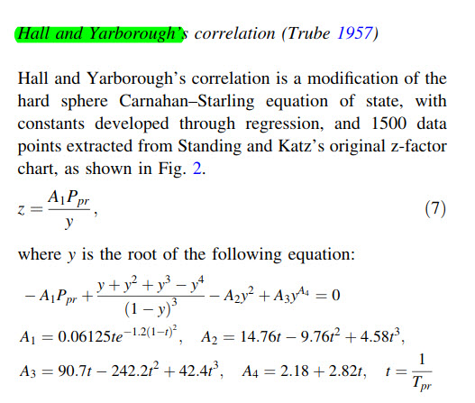

## From book Guo, Lyons, Galambor, Petroleum Production Eng.

The equations are OK bt in the worksheet they use $P_{pr}$ to find $T_{pr}$. The Excel workshet is included in this repository for analysis.

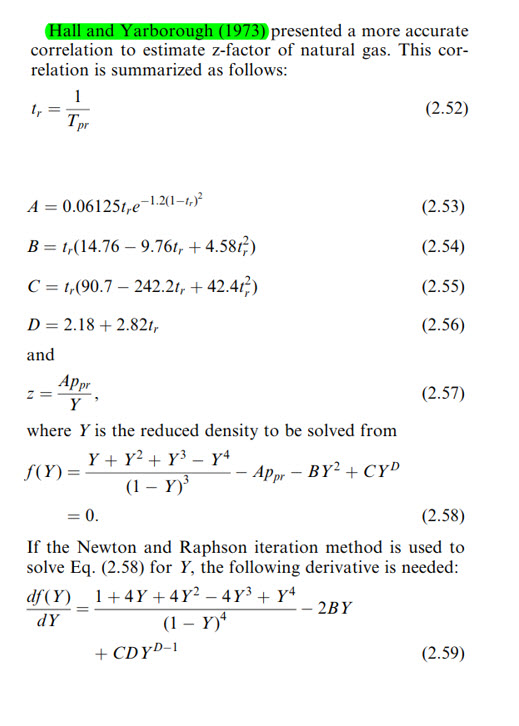

## From paper by Fatoorehchi, Abolghasemi, Rach and Assar

Link to paper: https://www.dropbox.com/s/3982pt63hi32p6c/10.1002%20cjce.22054%20-%20fatoorehchi2014.pdf?dl=0

### Hall-Yarborough equations

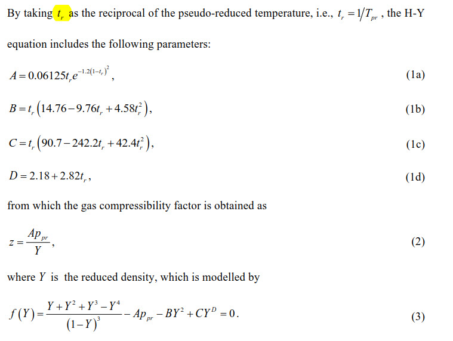

Hall-Yarborough equations

### Examples table

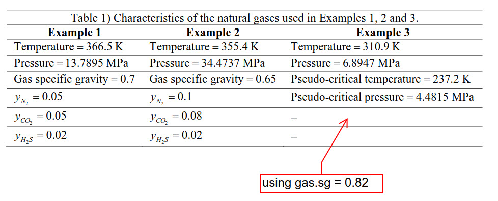

### Results. Fatoorachi

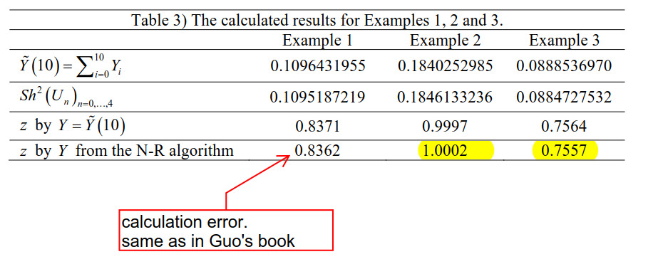

### Example 1. Fatoorechi paper

Find z given the data below:

```
Temperature = 366.5 K = 200 F
Pressure = 13.7895 MPa = 2000 psia
Gas specific gravity = 0.7
yN2 = 0.05
yCO2 = 0.05
yH2S = 0.02
```

We convert to oilfield units (Farenheit and psia).

```r
library(rNodal)
# Example 1 in Fantoorechi paper

print(z.hallyarborough(pres.a = 2000, temp.f = 200, gas.sg = 0.7,
                       n2.frac = 0.05, co2.frac = 0.05, h2s.frac = 0.02))
```

```
[1] "Guo 2/23"
[1] 0.8849235
```

If we compare the value obtained with the value in the paper, $z(NR) = 0.8362$.

Let’s use the internal function `z.hallyarboroughL` to check all the calculated values to obtain `z`.

```r
# use the internal function z.hallyarboroughL
print(rNodal:::z.hallyarboroughL(pres.a = 2000, temp.f = 200, gas.sg = 0.7,
                       n2.frac = 0.05, co2.frac = 0.05, h2s.frac = 0.02))
```

```
[1] "Guo 2/23"
$z
[1] 0.8849235

$Y
[1] 0.09114613

$A
[1] 0.02789934

$B
[1] 6.0835

$C
[1] -19.01769

$D
[1] 3.785012

$pres.pr
[1] 2.891013

$temp.pr
[1] 1.756997

$pres.pc
[1] 691.799

$temp.pc
[1] 375.641

$temp.r
[1] 0.569153
```

Using the equation for impurities in gas:

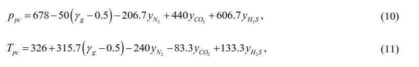

```r
# applying equation 11
gas.sg <- 0.7
n2.frac = 0.05
co2.frac = 0.05
h2s.frac = 0.02

temp.pc <- 326 + 315.7 * (gas.sg - 0.5) - 240 * n2.frac -
              83.3 * co2.frac + 133.3 * h2s.frac
print(temp.pc)
```

```
[1] 375.641
```

```r
# 375.641 R = 208.6894 K
```

Which gives us 208.7 Kelvin,

```r
# from Fatorechi paper:
# Table 1, Example 1 solution
pres.pc.M <- 4.7697  # Mpa

# All temperatures in Kelvin
temp.K    <- 366.5   # sample temperature, Kelvin
temp.pc.K <- 208.6   # pseudo-critical temperature, Kelvin
temp.r <-  temp.pc.K / temp.K  # reduced temperature, adimensional
print(temp.r)
```

```
[1] 0.5691678
```

This value is different of what is shown in the solution of example 1 in the paper.

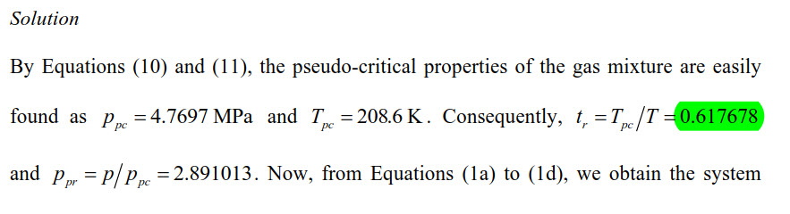

Solution Example 1

```r
# To double check the calculation, we run it in Farenheit (Rankine), not Kelvin.
# All temperatures in Rankine now
temp.F <- 200
temp.R <- temp.F + 460
temp.r <- temp.pc / temp.R
print(temp.r)
```

```
[1] 0.569153
```

> Note. Definitely, something is not right: `0.569153` not equal to `0.617678`.

Performing the reverse process: calculating the sampling temperature from the reduced temperature.

```r
# calculating the sampling temperature from the reduced temperature.
# from the solution in Example 1, Fatoorechi
temp.pc.K <- 208.6 # Kelvin
temp.r    <- 0.617678
temp.K <-  temp.pc.K / temp.r
print(temp.K)
```

```
[1] 337.7164
```

> Note: 337.7164 Kelvin is not equal either to 366.5 K given in the example.

## Example 2 from Fatoorechi paper

Given the second set of data, calculate Z.

```
Temperature = 355.4 K = 180 F
Pressure = 34.4747 MPa = 5000 psi
Gas specific gravity = 0.65
yN2 = 0.1
yCO2 = 0.08
yH2S = 0.02
```

We convert the Kelvin to Farenheit.

```r
library(rNodal)

# Example 2 in Fantoorechi paper

print(z.hallyarborough(pres.a = 5000, temp.f = 180, gas.sg = 0.65,
                       n2.frac = 0.1, co2.frac = 0.08, h2s.frac = 0.02))
```

```
[1] "Guo 2/23"
[1] 1.000311
```

From the paper, $z = 1.0002$.

## Example 3 from Fatoorechi paper

```
Temperature = 310.9 K = 100 F
Pressure = 6.8947 MPa = 1000 psi
Gas specific gravity =  ?
Tpc = 237.2 K  = -32.71 F = 427.29 R
Ppc = 4.4815 MPa = 650 psia
```

In this example the sepecific gravity of the gas is not provided.

```r
print(rNodal:::z.hallyarboroughL(pres.a = 1000, temp.f = 100, gas.sg = 0.82)$z)
```

```
[1] "Guo 2/23"
[1] 0.760227
```

```r
# z = 0.760227
# from paper, z = 0.7557
```

From the paper, $z = 0.7557$. The difference is very small.

## Modifying the `rNodal` script to accept multiple parameters

We do this in order to enter not only sampling pressure and temperature but also be able to provide pseudo-critical and pseudo-reduced pressures and temperatures as well.

```r
source("../R/HY.R")      # modified script saved as HY.R

# supplying gas.sg
with_gas.sg <- c(method = "use_gas.sg",
                 z.hallyarboroughL(pres.a = 1000, temp.f = 100, gas.sg = 0.82))
# z = 0.760227
# pres.pc = 662
# temp.pc = 427.024

# no gas.sg provided
with_pseudo_crit <- c(method = "use_pseudo_critical",
                      z.hallyarboroughL(pres.a = 1000, temp.f = 100,
                                        pres.pc = 662, temp.pc = 427))

# no gas.sg provided
with_pseudo_red <- c(method = "use_pseudo_reduced",
                     z.hallyarboroughL(pres.a = 1000, temp.f = 100,
                                       pres.pr = 1.51, temp.pr = 1.31))

only_pseudo_red <- c(method = "only_pseudo_reduced",
                     z.hallyarboroughL(pres.pr = 1.51, temp.pr = 1.31))

# put the results in a dataframe
df <- data.frame(stringsAsFactors = FALSE)
df <- rbind(df, with_gas.sg, with_pseudo_crit, with_pseudo_red, only_pseudo_red)
```

```
gas.sg has been provided. Will calculate Ppc, Tpc, Ppr, Tpr
No gas.sg supplied. Using instead Ppc and Tpc
No gas.sg supplied. Using instead pres.pr and temp.pr
No gas.sg supplied. Using ONLY pres.pr and temp.pr to calculate z
```

### Calculate `z` for various values of $P_{pr}$ and $T_{pr}$

## Limits of Hall-Yarborough correlation